# Untitled (2)

## ii. Find outliers in the dataset using Cook’s distance and standardized residuals. If required remove and report the observations from the dataset.

```python
final_XX['sold_price'] = y;final_XX.head()
```

|  | AGE | PLAYING ROLE | T-RUNS-S | T-WKTS | ODI-SR-B | ODI-SR-BL | CAPTAINCY EXP | AVE-B | SR-B | SIXERS | RUNS-C | AVE-BL | ECON | AUCTION YEAR | sold_price |
| --- | --- | --- | --- | --- | --- | --- | --- | --- | --- | --- | --- | --- | --- | --- | --- |
| 0 | 0.0 | -0.5 | -0.182246 | -0.147368 | -3.700331 | -0.807501 | 0.0 | -1.032553 | -3.839624 | -0.208696 | 0.014509 | -0.121276 | 0.184298 | 0.333333 | -0.693147 |
| 1 | 0.0 | 0.5 | -0.110355 | 0.231579 | -0.322375 | 0.022063 | 0.0 | -1.032553 | -3.839624 | -0.208696 | -0.388828 | -0.696599 | 0.863292 | 0.000000 | -0.693147 |
| 2 | 0.0 | 0.5 | 0.009574 | 1.073684 | 0.113292 | -0.081633 | 0.0 | -0.004156 | 0.080998 | -0.034783 | 1.105550 | 0.329820 | 0.173386 | 0.000000 | 1.252763 |
| 3 | -1.0 | 0.5 | -0.086840 | 0.505263 | 0.299669 | 0.004413 | 0.0 | -0.711179 | -1.366920 | -0.208696 | 1.201306 | -0.051293 | -0.139436 | 1.000000 | 2.140066 |
| 4 | 0.0 | 0.0 | -0.161082 | -0.147368 | -1.527673 | -0.807501 | 0.0 | 0.792076 | 0.071278 | 0.765217 | -0.430903 | -0.696599 | -0.894817 | 1.000000 | 2.079442 |

```python
final_XX.columns = final_XX.columns.str.replace(' ', '_')
final_XX.columns = final_XX.columns.str.replace('-', '_')
```

```python
final_XX.head()
```

|  | AGE | PLAYING_ROLE | T_RUNS_S | T_WKTS | ODI_SR_B | ODI_SR_BL | CAPTAINCY_EXP | AVE_B | SR_B | SIXERS | RUNS_C | AVE_BL | ECON | AUCTION_YEAR | sold_price |
| --- | --- | --- | --- | --- | --- | --- | --- | --- | --- | --- | --- | --- | --- | --- | --- |
| 0 | 0.0 | -0.5 | -0.182246 | -0.147368 | -3.700331 | -0.807501 | 0.0 | -1.032553 | -3.839624 | -0.208696 | 0.014509 | -0.121276 | 0.184298 | 0.333333 | -0.693147 |
| 1 | 0.0 | 0.5 | -0.110355 | 0.231579 | -0.322375 | 0.022063 | 0.0 | -1.032553 | -3.839624 | -0.208696 | -0.388828 | -0.696599 | 0.863292 | 0.000000 | -0.693147 |
| 2 | 0.0 | 0.5 | 0.009574 | 1.073684 | 0.113292 | -0.081633 | 0.0 | -0.004156 | 0.080998 | -0.034783 | 1.105550 | 0.329820 | 0.173386 | 0.000000 | 1.252763 |
| 3 | -1.0 | 0.5 | -0.086840 | 0.505263 | 0.299669 | 0.004413 | 0.0 | -0.711179 | -1.366920 | -0.208696 | 1.201306 | -0.051293 | -0.139436 | 1.000000 | 2.140066 |
| 4 | 0.0 | 0.0 | -0.161082 | -0.147368 | -1.527673 | -0.807501 | 0.0 | 0.792076 | 0.071278 | 0.765217 | -0.430903 | -0.696599 | -0.894817 | 1.000000 | 2.079442 |

```python
from statsmodels.formula.api import ols

m = ols('y ~ AGE	+PLAYING_ROLE	+T_RUNS_S	+T_WKTS	+ODI_SR_B	+ODI_SR_BL	+CAPTAINCY_EXP	+AVE_B	+SR_B	+SIXERS	+RUNS_C+AVE_BL+ECON	+AUCTION_YEAR',final_XX).fit()
infl = m.get_influence()
sm_fr = infl.summary_frame()
sm_fr['cooks_d']
```

```
0      0.031316
1      0.044014
2      0.000117
3      0.005473
4      0.008132
         ...
125    0.051920
126    0.000018
127    0.006120
128    0.000698
129    0.005786
Name: cooks_d, Length: 130, dtype: float64
```

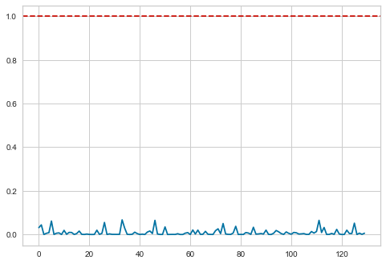

```python
_ = plt.plot(sm_fr['cooks_d'],)
_ = plt.axhline(y=1,color = 'r',linestyle = '--' )
```

As we see no tuple exceed the cook's Distance

## iii. What are the assumptions to be validated in a linear regression model?

#### The residuals should be randomly scattered and give a bayesian distribution, very much like in the figure below.

#### Which satisfies the assumption of the normality of the residuals.

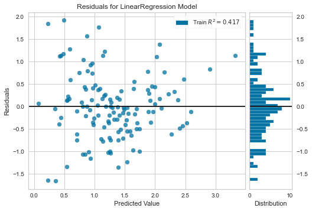

```python
from yellowbrick.regressor import ResidualsPlot

# Instantiate and fit the visualizer
model = LinearRegression()
visualizer_residuals = ResidualsPlot(model)
_ = visualizer_residuals.fit(XX, y)
_ = visualizer_residuals.show()
```

#### The Dep and Indep must have Linear Relationship

```python
final_XX.columns
```

```
Index(['AGE', 'PLAYING_ROLE', 'T_RUNS_S', 'T_WKTS', 'ODI_SR_B', 'ODI_SR_BL',
       'CAPTAINCY_EXP', 'AVE_B', 'SR_B', 'SIXERS', 'RUNS_C', 'AVE_BL', 'ECON',
       'AUCTION_YEAR', 'sold_price'],
      dtype='object')
```

```python
final_XX.columns
```

```
Index(['AGE', 'PLAYING_ROLE', 'T_RUNS_S', 'T_WKTS', 'ODI_SR_B', 'ODI_SR_BL',
       'CAPTAINCY_EXP', 'AVE_B', 'SR_B', 'SIXERS', 'RUNS_C', 'AVE_BL', 'ECON',
       'AUCTION_YEAR', 'sold_price'],
      dtype='object')
```

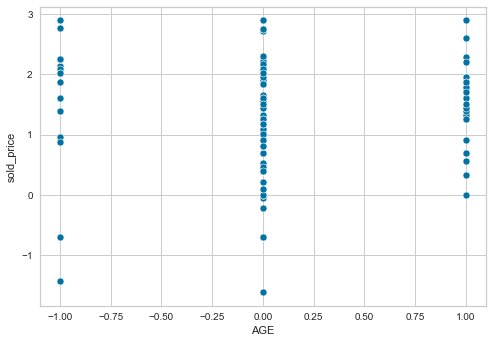

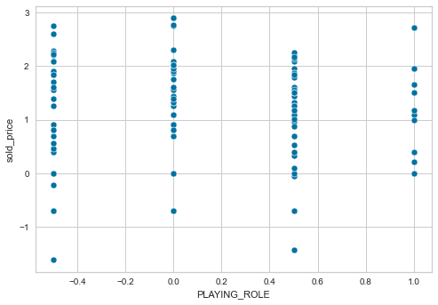

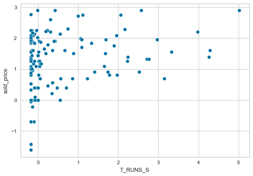

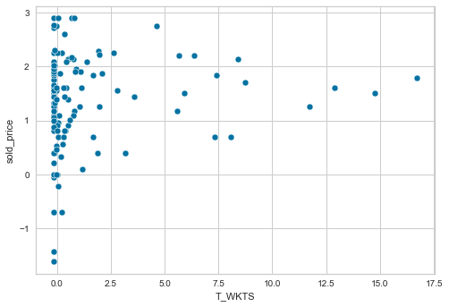

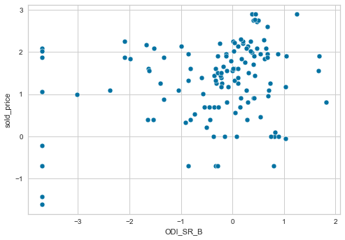

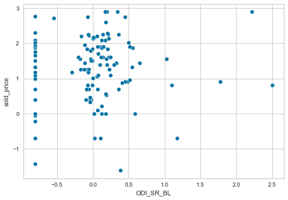

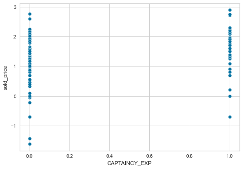

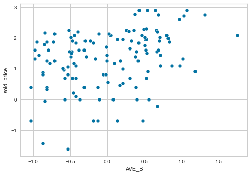

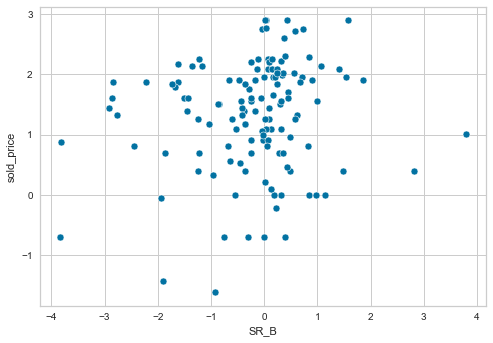

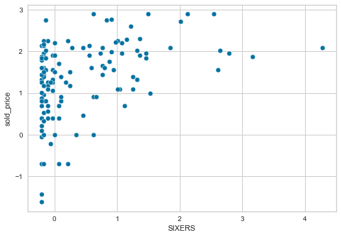

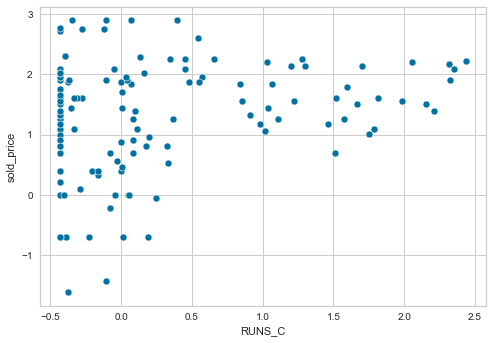

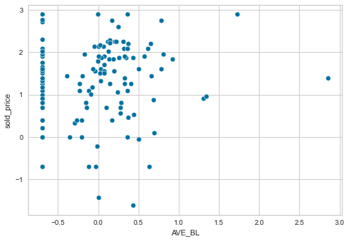

[3 more figures not shown]

```python
for i, col in enumerate(final_XX.columns):
    plt.figure(i)
    sns.scatterplot(x=col,y = 'sold_price', data=final_XX)
```

We see that many do not have a linear relationship with the targert variable the two reasons for that are firstly, qualitative variables like age when Lable Encoded with give only a set of Integer values which in no way will be linear. For the rest we can transform the data like taking the sqaure root, taking the log transformation, taking the sqaure et cetera

### No Autocorrelation in Residuals

```python
X_poly = sm.add_constant(XX)
res = sm.OLS(y,X_poly).fit()
print(res.summary())
```

```
                            OLS Regression Results
==============================================================================
Dep. Variable:             SOLD PRICE   R-squared:                       0.417
Model:                            OLS   Adj. R-squared:                  0.309
Method:                 Least Squares   F-statistic:                     3.891
Date:                Thu, 03 Dec 2020   Prob (F-statistic):           2.18e-06
Time:                        11:57:04   Log-Likelihood:                -139.37
No. Observations:                 130   AIC:                             320.7
Df Residuals:                     109   BIC:                             381.0
Df Model:                          20
Covariance Type:            nonrobust
=================================================================================
                    coef    std err          t      P>|t|      [0.025      0.975]
---------------------------------------------------------------------------------
const             0.7733      0.154      5.018      0.000       0.468       1.079
AGE              -0.0735      0.157     -0.468      0.640      -0.385       0.238
PLAYING ROLE      0.0676      0.171      0.395      0.694      -0.272       0.407
T-RUNS-S         -0.1087      0.170     -0.637      0.525      -0.446       0.229
T-WKTS            0.0071      0.052      0.135      0.893      -0.097       0.111
ODI-RUNS-S        0.1724      0.206      0.836      0.405      -0.236       0.581
ODI-SR-B          0.0883      0.070      1.269      0.207      -0.050       0.226
ODI-WKTS          0.1283      0.148      0.866      0.388      -0.165       0.422
ODI-SR-BL        -0.1549      0.143     -1.080      0.283      -0.439       0.129
CAPTAINCY EXP     0.3468      0.231      1.503      0.136      -0.111       0.804
RUNS-S            0.5112      0.260      1.968      0.052      -0.004       1.026
HS               -0.3906      0.286     -1.366      0.175      -0.957       0.176
AVE-B             0.4052      0.263      1.538      0.127      -0.117       0.927
SR-B             -0.0551      0.080     -0.690      0.492      -0.214       0.103
SIXERS            0.0622      0.189      0.329      0.743      -0.313       0.437
RUNS-C            0.3925      0.363      1.080      0.283      -0.328       1.113
WKTS              0.0039      0.320      0.012      0.990      -0.630       0.638
AVE-BL            0.4407      0.739      0.596      0.552      -1.024       1.906
ECON             -0.2176      0.181     -1.203      0.232      -0.576       0.141
SR-BL            -0.2490      0.742     -0.336      0.738      -1.719       1.221
AUCTION YEAR      0.1208      0.167      0.722      0.472      -0.211       0.452
==============================================================================
Omnibus:                        2.427   Durbin-Watson:                   2.001
Prob(Omnibus):                  0.297   Jarque-Bera (JB):                2.016
Skew:                          -0.296   Prob(JB):                        0.365
Kurtosis:                       3.151   Cond. No.                         54.1
==============================================================================

Notes:
[1] Standard Errors assume that the covariance matrix of the errors is correctly specified.
```

```python
# another assumption is that the residuals should not have Autocorrelation here we see that Durbin-Watson: gives us 2.001
#which is almost ideal value for no autocorrelation
```

### No Heteroskedasticity.

```python
#funnel shape would be seen in the scatter plot of RESIDUALS and FITTED VALUES
```

[figure not shown]

```python
preds = cross_val_predict(linr,X_val_rs,y_val)
```

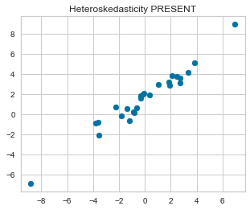

```python
_ = plt.figure(figsize=(5,4))
_ = plt.scatter(preds-(y_val),preds)
_ = plt.title('Heteroskedasticity PRESENT')
```

```python
#usually transforming the target variable works,here I had already taken Log transformation before so I'm taking exp to take
#original target values
```

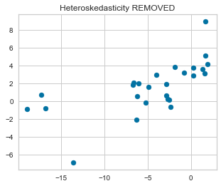

```python
_ = plt.figure(figsize=(5,4))
_ = plt.scatter(preds-np.exp(y_val),preds)
_ = plt.title('Heteroskedasticity REMOVED')
```

### No Multicollinearity

```python
# we have already dealt with this usinf VIF Variance Inflation factor
```

[figure not shown]

```python
# we have also removed the neccesary features that had VIF
```

### vi. Which features are statistically significant in predicting the SOLD PRICE of a player?

```python
print(sm.OLS(y,final_XX,random_state=0).fit().summary())
```

```
                                 OLS Regression Results
=======================================================================================
Dep. Variable:             SOLD PRICE   R-squared (uncentered):                   1.000
Model:                            OLS   Adj. R-squared (uncentered):              1.000
Method:                 Least Squares   F-statistic:                          5.400e+30
Date:                Thu, 03 Dec 2020   Prob (F-statistic):                        0.00
Time:                        12:36:55   Log-Likelihood:                          4221.7
No. Observations:                 130   AIC:                                     -8413.
Df Residuals:                     115   BIC:                                     -8370.
Df Model:                          15
Covariance Type:            nonrobust
=================================================================================
                    coef    std err          t      P>|t|      [0.025      0.975]
---------------------------------------------------------------------------------
AGE            5.733e-16   3.99e-16      1.438      0.153   -2.16e-16    1.36e-15
PLAYING_ROLE  -4.567e-16   4.37e-16     -1.045      0.298   -1.32e-15    4.09e-16
T_RUNS_S       2.956e-16   2.55e-16      1.160      0.248   -2.09e-16       8e-16
T_WKTS        -3.519e-16   7.44e-17     -4.733      0.000   -4.99e-16   -2.05e-16
ODI_SR_B      -1.002e-15   1.75e-16     -5.725      0.000   -1.35e-15   -6.55e-16
ODI_SR_BL      9.154e-16   3.73e-16      2.456      0.016    1.77e-16    1.65e-15
CAPTAINCY_EXP  2.454e-16   5.61e-16      0.438      0.663   -8.65e-16    1.36e-15
AVE_B          3.621e-16   5.15e-16      0.704      0.483   -6.57e-16    1.38e-15
SR_B          -2.277e-17   2.01e-16     -0.113      0.910   -4.21e-16    3.75e-16
SIXERS        -8.205e-16   3.16e-16     -2.594      0.011   -1.45e-15   -1.94e-16
RUNS_C        -2.177e-16    2.9e-16     -0.751      0.454   -7.92e-16    3.57e-16
AVE_BL         4.606e-16      5e-16      0.921      0.359   -5.29e-16    1.45e-15
ECON           2.384e-16   4.55e-16      0.524      0.601   -6.63e-16    1.14e-15
AUCTION_YEAR   1.209e-16   3.94e-16      0.307      0.759   -6.59e-16    9.01e-16
sold_price        1.0000    2.1e-16   4.77e+15      0.000       1.000       1.000
==============================================================================
Omnibus:                        1.159   Durbin-Watson:                   2.018
Prob(Omnibus):                  0.560   Jarque-Bera (JB):                0.722
Skew:                          -0.065   Prob(JB):                        0.697
Kurtosis:                       3.341   Cond. No.                         11.7
==============================================================================

Notes:
[1] R² is computed without centering (uncentered) since the model does not contain a constant.
[2] Standard Errors assume that the covariance matrix of the errors is correctly specified.
```

```python
final_xxx = final_XX
#final_xxx.drop('sold_price',axis = 1,inplace = True)
final_xxx = sm.add_constant(final_xxx)
final_xxx.head()
```

[output not shown]

Below Code automatically detects p values greater than 0.05 and removes them and does this step by step

```python
for _ in range(14):
  model=sm.OLS(y,final_xxx,random_state=0)
  result=model.fit()
  print(result.summary())
  p = pd.DataFrame(result.pvalues)
  p.columns = ['p_vals']
  shit = np.argmax(p['p_vals'])
  #print(shit,max((p['p_vals'])))
  #XX_trn = XX_trn.drop([shit],axis = 1)
  final_xxx = final_xxx.drop(final_xxx.columns[shit], axis=1)
  if max(p.values) < .051:
    break
```

```
                            OLS Regression Results
==============================================================================
Dep. Variable:             SOLD PRICE   R-squared:                       0.373
Model:                            OLS   Adj. R-squared:                  0.297
Method:                 Least Squares   F-statistic:                     4.896
Date:                Thu, 03 Dec 2020   Prob (F-statistic):           4.91e-07
Time:                        12:40:18   Log-Likelihood:                -144.00
No. Observations:                 130   AIC:                             318.0
Df Residuals:                     115   BIC:                             361.0
Df Model:                          14
Covariance Type:            nonrobust
=================================================================================
                    coef    std err          t      P>|t|      [0.025      0.975]
---------------------------------------------------------------------------------
const             0.8292      0.132      6.265      0.000       0.567       1.091
AGE              -0.0724      0.153     -0.473      0.637      -0.376       0.231
PLAYING_ROLE      0.1076      0.168      0.642      0.522      -0.224       0.440
T_RUNS_S          0.0747      0.098      0.764      0.446      -0.119       0.268
T_WKTS            0.0361      0.029      1.259      0.211      -0.021       0.093
ODI_SR_B          0.1032      0.068      1.516      0.132      -0.032       0.238
ODI_SR_BL        -0.1308      0.143     -0.916      0.361      -0.413       0.152
CAPTAINCY_EXP     0.3590      0.217      1.656      0.100      -0.070       0.788
AVE_B             0.3075      0.203      1.517      0.132      -0.094       0.709
SR_B             -0.0699      0.077     -0.908      0.366      -0.222       0.083
SIXERS            0.2848      0.121      2.345      0.021       0.044       0.525
RUNS_C            0.3771      0.106      3.564      0.001       0.168       0.587
AVE_BL            0.2107      0.192      1.100      0.274      -0.169       0.590
ECON             -0.1386      0.174     -0.796      0.428      -0.484       0.207
AUCTION_YEAR      0.1523      0.166      0.918      0.360      -0.176       0.481
==============================================================================
Omnibus:                        2.030   Durbin-Watson:                   2.006
Prob(Omnibus):                  0.362   Jarque-Bera (JB):                1.789
Skew:                          -0.287   Prob(JB):                        0.409
Kurtosis:                       3.025   Cond. No.                         11.7
==============================================================================

Notes:
[1] Standard Errors assume that the covariance matrix of the errors is correctly specified.
                            OLS Regression Results
==============================================================================
```

[output cut: 335 more lines]

```
                    coef    std err          t      P>|t|      [0.025      0.975]
---------------------------------------------------------------------------------
const             0.8538      0.093      9.226      0.000       0.671       1.037
CAPTAINCY_EXP     0.5592      0.157      3.564      0.001       0.249       0.870
SIXERS            0.4243      0.085      4.985      0.000       0.256       0.593
RUNS_C            0.3962      0.088      4.520      0.000       0.223       0.570
==============================================================================
Omnibus:                        3.893   Durbin-Watson:                   2.059
Prob(Omnibus):                  0.143   Jarque-Bera (JB):                3.461
Skew:                          -0.391   Prob(JB):                        0.177
Kurtosis:                       3.164   Cond. No.                         3.08
==============================================================================

Notes:
[1] Standard Errors assume that the covariance matrix of the errors is correctly specified.
```

```python
print('Significant Feature which determine Sold Price',final_xxx.columns.values)
```

[output not shown]